# Multiple Imputation and Bootstrapping - Method boot_MI

Martijn W Heymans

2020-09-24

# 1 Introduction

This page contains information of the `boot_MI` method that is implemented in the `psfmi_perform` function of the [`psfmi`](https://github.com/mwheymans/psfmi) package and that combines Multiple Imputation with bootstrapping for the validation of logistic regression / prediction models. Internal validation is done of the last model that is selected by the function `psfmi_lr`. An explanation and examples of how to use the methods can be found below.

# 2 Method boot_MI

With the method boot_MI, first bootstrap samples are drawn from the original dataset with missing values and than multiple imputation is applied in each bootstrap sample. The pooled model is analyzed in the each bootstrap training data and subsequently tested in original multiply imputed data. The method can be performed in combination with backward or forward selection selection.

How these steps work is visualized in the Figure below.

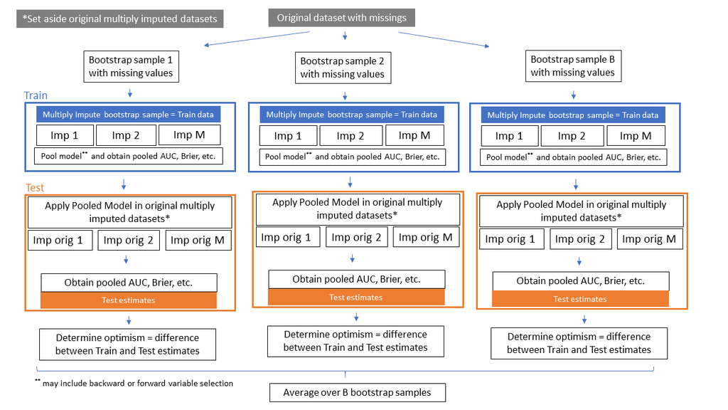

Figure 2.1: Schematic overview of the boot_MI method

# 3 Examples

- Method boot_MI
- Method boot_MI including BW selection
- Method boot_MI including FW selection

## 3.1 Method boot_MI

internal validation is done of the last model that is selected by the function `psfmi_lr`. In the example below, `psfmi_lr` is used with `p.crit` set at 1. This setting is also used and in the `psfmi_perform` function. This means that first the full model is pooled and subsequently interval validation is also done of this full model.

```r
library(psfmi)
pool_lr <- psfmi_lr(data=lbpmilr, formula = Chronic ~ Pain + JobDemands + rcs(Tampascale, 3) +
                   factor(Satisfaction) + Smoking, p.crit = 1, direction="FW",
                 nimp=5, impvar="Impnr", method="D1")

res_MI_boot <- psfmi_perform(pool_lr, val_method = "boot_MI", data_orig = lbp_orig, nboot = 5,
                     p.crit=1, nimp_mice = 3, direction = "BW", miceImp = miceImp,
                     printFlag = FALSE)
```

```
##
## Boot 1
```

```
##
## Boot 2
```

```
##
## Boot 3
```

```
##
## Boot 4
```

```
##
## Boot 5
```

```
##
## p.crit = 1, validation is done without variable selection
```

```r
res_MI_boot
```

```
## $stats_val
##                   Orig  Apparent      Test   Optimism Corrected
## AUC          0.8871000 0.9033000 0.8765800 0.02672000 0.8603800
## R2           0.5605521 0.6076112 0.5307290 0.07688221 0.4836699
## Brier Scaled 0.4514569 0.4991465 0.4122721 0.08687432 0.3645826
## Slope        1.0000000 1.0000000 0.8265696 0.17343036 0.8265696
##
## $intercept_test
##   intercept
## -0.09921869
##
## $res_boot
##        ROC_app ROC_test    R2_app   R2_test Brier_sc_app Brier_sc_test
## Boot 1  0.8986   0.8857 0.5748913 0.5467043    0.4557457     0.4240552
## Boot 2  0.9178   0.8790 0.6667569 0.5412814    0.5841894     0.4343451
## Boot 3  0.8966   0.8834 0.5917839 0.5476373    0.4697460     0.4214247
## Boot 4  0.8995   0.8792 0.5881709 0.5347974    0.4991174     0.4301919
## Boot 5  0.9040   0.8556 0.6164528 0.4832243    0.4869337     0.3513437
##          intercept     Slope
## Boot 1 -0.10477141 0.8685152
## Boot 2  0.03905404 0.6860926
## Boot 3 -0.34670915 0.9631026
## Boot 4  0.10476835 0.8555809
## Boot 5 -0.18843528 0.7595569
```

Back to Examples

## 3.2 Method boot_MI including BW selection

Internal validation is done of the last model that is selected by the function `psfmi_lr`. In the example below, `psfmi_lr` is used with `p.crit` set at 1, and pooling is than done without variable selection, i.e. first the full model is pooled. When subsequently interval validation is done with the `psfmi_perform` function including BW, BW is applied in each bootstrap sample from the full model.

```r
library(psfmi)
pool_lr <- psfmi_lr(data=lbpmilr, Outcome="Chronic", predictors = c("Pain", "JobDemands", "Smoking"),
                   cat.predictors = "Satisfaction", spline.predictors = "Tampascale", nknots=3,
                   p.crit = 1, direction="FW", nimp=5, impvar="Impnr", method="D1")

res_MI_boot <- psfmi_perform(pool_lr, val_method = "boot_MI", data_orig = lbp_orig, nboot = 5,
                     p.crit=0.05, nimp_mice = 3, direction = "BW", miceImp = miceImp,
                     printFlag = FALSE)
```

```
##
## Boot 1
```

```
## Removed at Step 1 is - JobDemands
```

```
## Removed at Step 2 is - Smoking
```

```
## Removed at Step 3 is - rcs(Tampascale,3)
```

```
##
## Selection correctly terminated,
## No more variables removed from the model
```

```
##
## Boot 2
```

```
## Removed at Step 1 is - JobDemands
```

```
## Removed at Step 2 is - Pain
```

```
## Removed at Step 3 is - Smoking
```

```
##
## Selection correctly terminated,
## No more variables removed from the model
```

```
##
## Boot 3
```

```
## Removed at Step 1 is - JobDemands
```

```
## Removed at Step 2 is - rcs(Tampascale,3)
```

```
##
## Selection correctly terminated,
## No more variables removed from the model
```

```
##
## Boot 4
```

```
## Removed at Step 1 is - JobDemands
```

```
## Removed at Step 2 is - Smoking
```

```
## Removed at Step 3 is - rcs(Tampascale,3)
```

```
## Removed at Step 4 is - factor(Satisfaction)
```

```
##
## Selection correctly terminated,
## No more variables removed from the model
```

```
##
## Boot 5
```

```
## Removed at Step 1 is - JobDemands
```

```
## Removed at Step 2 is - rcs(Tampascale,3)
```

```
## Removed at Step 3 is - Smoking
```

```
## Removed at Step 4 is - factor(Satisfaction)
```

```
##
## Selection correctly terminated,
## No more variables removed from the model
```

```r
res_MI_boot
```

```
## $stats_val
##                   Orig  Apparent      Test   Optimism Corrected
## AUC          0.8871000 0.8675400 0.8486600 0.01888000 0.8682200
## R2           0.5605521 0.5158842 0.4678360 0.04804823 0.5125039
## Brier Scaled 0.4514569 0.4257104 0.3697809 0.05592955 0.3955274
## Slope        1.0000000 1.0000000 0.8915697 0.10843035 0.8915697
##
## $intercept_test
##  intercept
## 0.05263674
##
## $res_boot
##        ROC_app ROC_test    R2_app   R2_test Brier_sc_app Brier_sc_test
## Boot 1  0.9034   0.8414 0.6081386 0.4741075    0.5137106     0.3669051
## Boot 2  0.8833   0.8556 0.5458448 0.4783700    0.4333424     0.3370175
## Boot 3  0.8725   0.8563 0.5375735 0.4863413    0.4508174     0.4038069
## Boot 4  0.8412   0.8450 0.4448085 0.4501806    0.3650045     0.3673242
## Boot 5  0.8373   0.8450 0.4430559 0.4501806    0.3656770     0.3738506
##          intercept     Slope
## Boot 1  0.08803902 0.7578973
## Boot 2 -0.23768888 0.7821832
## Boot 3  0.19396899 0.9352751
## Boot 4  0.30042374 0.9852542
## Boot 5 -0.08155918 0.9972385
```

Back to Examples

## 3.3 Method boot_MI including FW selection

Internal validation is done of the last model that is selected by the function `psfmi_lr`. In the example below, `psfmi_lr` is used with `p.crit` set at 1, and pooling is than done without variable selection, i.e. first the full model is pooled. When subsequently interval validation is done with the `psfmi_perform` function including FW, FW is applied in each bootstrap sample from the full model.

```r
library(psfmi)
pool_lr <- psfmi_lr(data=lbpmilr, formula = Chronic ~ Pain + JobDemands + rcs(Tampascale, 3) +
                   factor(Satisfaction) + Smoking, p.crit = 1, direction="FW",
                 nimp=5, impvar="Impnr", method="D1")

res_MI_boot <- psfmi_perform(pool_lr, val_method = "boot_MI", data_orig = lbp_orig, nboot = 5,
                     p.crit=0.05, nimp_mice = 3, direction = "FW", miceImp = miceImp,
                     printFlag = FALSE)
```

```
##
## Boot 1
```

```
## Entered at Step 1 is - Pain
```

```
## Entered at Step 2 is - rcs(Tampascale,3)
```

```
## Entered at Step 3 is - factor(Satisfaction)
```

```
##
## Selection correctly terminated,
## No new variables entered the model
```

```
##
## Boot 2
```

```
## Entered at Step 1 is - Pain
```

```
## Entered at Step 2 is - factor(Satisfaction)
```

```
##
## Selection correctly terminated,
## No new variables entered the model
```

```
##
## Boot 3
```

```
## Entered at Step 1 is - Pain
```

```
## Entered at Step 2 is - factor(Satisfaction)
```

```
## Entered at Step 3 is - rcs(Tampascale,3)
```

```
##
## Selection correctly terminated,
## No new variables entered the model
```

```
##
## Boot 4
```

```
## Entered at Step 1 is - Pain
```

```
## Entered at Step 2 is - factor(Satisfaction)
```

```
##
## Selection correctly terminated,
## No new variables entered the model
```

```
##
## Boot 5
```

```
## Entered at Step 1 is - Pain
```

```
## Entered at Step 2 is - factor(Satisfaction)
```

```
## Entered at Step 3 is - rcs(Tampascale,3)
```

```
##
## Selection correctly terminated,
## No new variables entered the model
```

```r
res_MI_boot
```

```
## $stats_val
##                   Orig  Apparent       Test  Optimism  Corrected
## AUC          0.8871000 0.8960800  0.6618800 0.2342000  0.6529000
## R2           0.5605521 0.5952339  0.1966421 0.3985918  0.1619604
## Brier Scaled 0.4514569 0.4811972 -0.7624482 1.2436454 -0.7921885
## Slope        1.0000000 1.0000000 -0.1297440 1.1297440 -0.1297440
##
## $intercept_test
## intercept
## -3.357985
##
## $res_boot
##        ROC_app ROC_test    R2_app    R2_test Brier_sc_app Brier_sc_test
## Boot 1  0.9042   0.5294 0.6136112 0.01522196    0.4967869    -0.7584502
## Boot 2  0.8587   0.4165 0.4987094 0.02239926    0.3865967    -0.7538605
## Boot 3  0.9281   0.8343 0.6810738 0.38082731    0.5684618    -0.7666667
## Boot 4  0.9217   0.7100 0.6582930 0.21705351    0.5491232    -0.7665967
## Boot 5  0.8677   0.8192 0.5244819 0.34770845    0.4050175    -0.7666667
##         intercept       Slope
## Boot 1  0.3069063  0.07602518
## Boot 2 -1.3393491 -0.17005915
## Boot 3 -5.7105637 -0.05125290
## Boot 4 -4.7142449 -0.38628532
## Boot 5 -5.3326725 -0.11714792
```